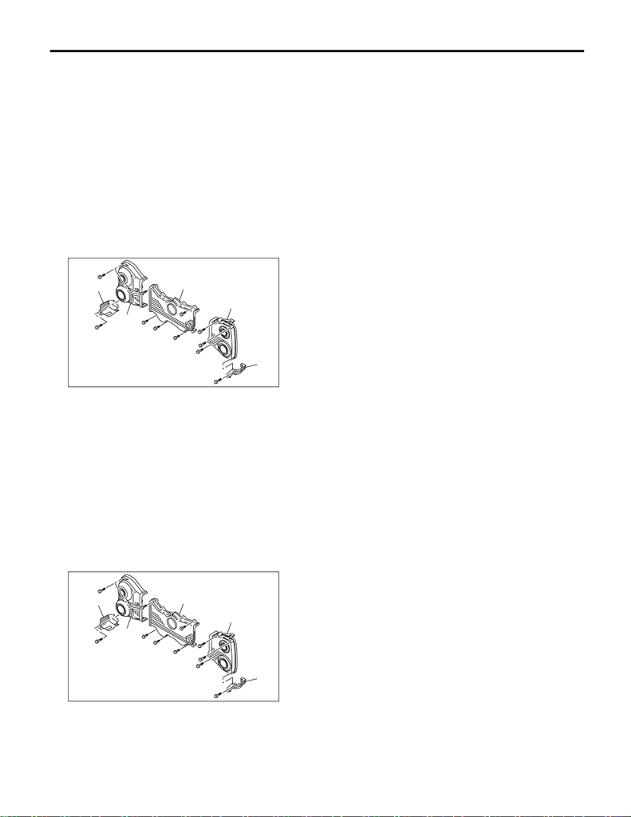

ME(STI)-50

Timing Belt Cover

MECHANICAL

14.Timing Belt Cover

A: REMOVAL

NOTE:

When replacing a single part, perform the work with

the engine assembly installed to body.

1) Remove the secondary air pump. <Ref. to

EC(STI)-53, REMOVAL, Secondary Air Pump.>

2) Remove the crank pulley. <Ref. to ME(STI)-48,

REMOVAL, Crank Pulley.>

3) Remove the timing belt cover RH (B) together

with the engine harness cover (A).

4) Remove the timing belt cover LH (D) together

with the engine harness stay (C).

5) Remove front timing belt cover (E).

B: INSTALLATION

1) Install front timing belt cover (E).

Tightening torque:

5 N·m (0.5 kgf-m, 3.7 ft-lb)

2) Install the timing belt cover LH (D) together with

the engine harness stay (C).

Tightening torque:

5 N·m (0.5 kgf-m, 3.7 ft-lb)

3) Install the timing belt cover RH (B) together with

the engine harness cover (A).

Tightening torque:

5 N·m (0.5 kgf-m, 3.7 ft-lb)

4) Install the crank pulley. <Ref. to ME(STI)-48, IN-

STALLATION, Crank Pulley.>

5) Install the secondary air pump. <Ref. to

EC(STI)-53, INSTALLATION, Secondary Air

Pump.>

C: INSPECTION

Check the timing belt cover for damage.

ME-08035

(A)

(E)

(D)

(B)

(C)

ME-08035

(A)

(E)

(D)

(B)

(C)